# Exploring Brand Perception and Repeat Purchase Behavior Through Unsupervised Learning

## 1 Preparation

### 1.1 Load Packages

```r
library(pacman)
p_load(tidyverse,tidymodels,here,gt,forcats,dpylr,recipes,GGally, gapminder,ggplot,corrplot,psych,factoextra, cluster, dendextend, broom, visdat )
```

### 1.2 Load Dataset

```r
brand <- here("Data/brand.csv") |> read.csv()

glimpse(brand)
```

```
Rows: 1,000
Columns: 10
$ performance   <int> 2, 1, 2, 1, 1, 2, 1, 2, 2, 3, 2, 1, 3, 1, 3, 3, 2, 3, 2,…
$ leadership    <int> 4, 1, 3, 6, 1, 8, 1, 1, 1, 1, 1, 2, 3, 5, 1, 2, 1, 8, 5,…
$ productLatest <int> 8, 4, 5, 10, 5, 9, 5, 7, 8, 9, 5, 7, 10, 7, 3, 7, 6, 9, …
$ fun           <int> 8, 7, 9, 8, 8, 5, 7, 5, 10, 8, 6, 7, 10, 10, 6, 6, 7, 9,…
$ serious       <int> 2, 1, 2, 3, 1, 3, 1, 2, 1, 1, 1, 2, 1, 2, 1, 1, 2, 4, 2,…
$ bargain       <int> 9, 1, 9, 4, 9, 8, 5, 8, 7, 3, 1, 3, 3, 1, 3, 10, 1, 7, 6…
$ bestValue     <int> 7, 1, 5, 5, 9, 7, 1, 7, 7, 3, 1, 2, 3, 3, 4, 5, 3, 10, 1…
$ trendiness    <int> 4, 2, 1, 2, 1, 1, 1, 7, 5, 4, 1, 1, 3, 3, 4, 1, 5, 4, 5,…
$ repeatBuy     <int> 6, 2, 6, 1, 1, 2, 1, 1, 1, 1, 2, 5, 3, 1, 2, 3, 1, 2, 2,…
$ name          <chr> "a", "a", "a", "a", "a", "a", "a", "a", "a", "a", "a", "…
```

## 2 Data Cleaning

### 2.1 Missing Values

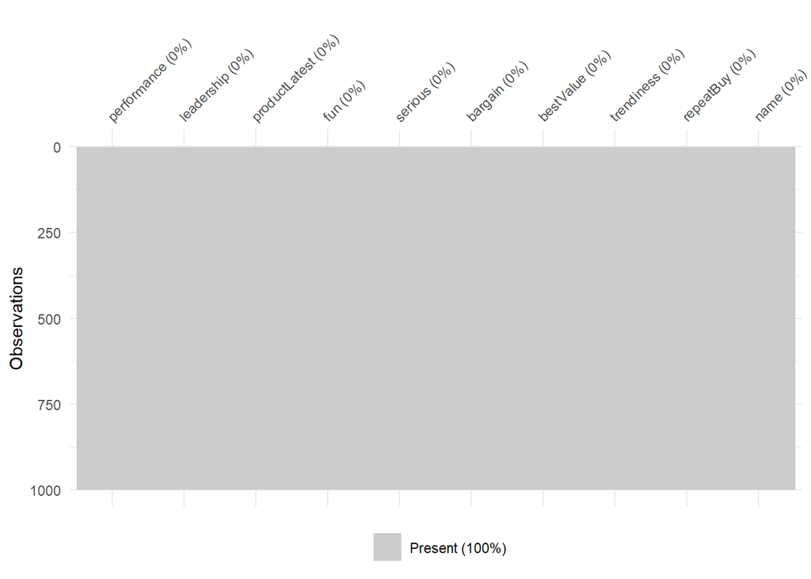

```r
# calculate the percentage amount of NA relative to the dataset population
percent_na = sum(is.na(brand)) / (nrow(brand) * ncol(brand))

# calculate the total NA
full_na = sum(is.na(brand))

# visualize the missing values
vis_miss(brand)
```

This dataset has no missing value.

### 2.2 Converting categorical variables into factors

```r
# Select numerical variables for correlation analysis
prepared_brand <- brand |>
  mutate(name = as_factor(name)) |>
  mutate(name = fct_recode(name,
                           "1" = "a",
                           "2" = "b",
                           "3" = "c",
                           "4" = "d",
                           "5" = "e",
                           "6" = "f",
                           "7" = "g",
                           "8" = "h",
                           "9" = "i",
                           "10" = "j"))


prepared_brand$name <- factor(prepared_brand$name, levels = as.character(1:10))

glimpse(prepared_brand)
```

```
Rows: 1,000
Columns: 10
$ performance   <int> 2, 1, 2, 1, 1, 2, 1, 2, 2, 3, 2, 1, 3, 1, 3, 3, 2, 3, 2,…
$ leadership    <int> 4, 1, 3, 6, 1, 8, 1, 1, 1, 1, 1, 2, 3, 5, 1, 2, 1, 8, 5,…
$ productLatest <int> 8, 4, 5, 10, 5, 9, 5, 7, 8, 9, 5, 7, 10, 7, 3, 7, 6, 9, …
$ fun           <int> 8, 7, 9, 8, 8, 5, 7, 5, 10, 8, 6, 7, 10, 10, 6, 6, 7, 9,…
$ serious       <int> 2, 1, 2, 3, 1, 3, 1, 2, 1, 1, 1, 2, 1, 2, 1, 1, 2, 4, 2,…
$ bargain       <int> 9, 1, 9, 4, 9, 8, 5, 8, 7, 3, 1, 3, 3, 1, 3, 10, 1, 7, 6…
$ bestValue     <int> 7, 1, 5, 5, 9, 7, 1, 7, 7, 3, 1, 2, 3, 3, 4, 5, 3, 10, 1…
$ trendiness    <int> 4, 2, 1, 2, 1, 1, 1, 7, 5, 4, 1, 1, 3, 3, 4, 1, 5, 4, 5,…
$ repeatBuy     <int> 6, 2, 6, 1, 1, 2, 1, 1, 1, 1, 2, 5, 3, 1, 2, 3, 1, 2, 2,…
$ name          <fct> 1, 1, 1, 1, 1, 1, 1, 1, 1, 1, 1, 1, 1, 1, 1, 1, 1, 1, 1,…
```

Converting the categorical variable into factors ensures that the distinct brand identities are properly encoded as discrete levels, allowing PCA and regression to accurately process and analyze the brand data.

### 2.3 Preprocessing steps

```r
brand_recipe <- recipe(repeatBuy ~ ., data = prepared_brand) |>
  step_normalize(all_numeric_predictors()) |>
  step_pca(performance, leadership, productLatest, fun, serious, bargain, bestValue, trendiness, num_comp = 3, id = "pca") |>
  step_dummy(all_nominal_predictors()) |>
  step_zv(all_predictors())

print(brand_recipe)
```

- **`step_normalize`** ensures all numeric predictors contribute equally, which is crucial for accurate distance calculations in clustering, unbiased principal components in PCA, and comparable coefficients in regression.
- **`step_pca`** reduces dimensionality by transforming variables into uncorrelated components, simplifying the dataset for easier visualization and interpretation in clustering, and improving regression model performance by focusing on the most important features.
- **`step_dummy`** converts categorical predictors into binary variables, enabling their use in PCA, cluster analysis, and regression models that require numerical input.
- **`step_zv`** Eliminates predictors with no variance to improve computational efficiency and ensure that only informative variables are used in clustering, PCA, and regression analyses.

## 3 Cluster Analysis

### 3.1 Descriptive analysis of numerical variables

```r
# Descriptive
describe(prepared_brand)
```

```
              vars    n mean   sd median trimmed  mad min max range  skew
performance      1 1000 4.49 3.20    4.0    4.24 4.45   1  10     9  0.43
leadership       2 1000 4.42 2.61    4.0    4.27 2.97   1  10     9  0.28
productLatest    3 1000 6.20 3.08    7.0    6.37 4.45   1  10     9 -0.35
fun              4 1000 6.07 2.74    6.0    6.18 2.97   1  10     9 -0.24
serious          5 1000 4.32 2.78    4.0    4.07 2.97   1  10     9  0.58
bargain          6 1000 4.26 2.67    4.0    4.07 2.97   1  10     9  0.37
bestValue        7 1000 4.34 2.40    4.0    4.21 2.97   1  10     9  0.33
trendiness       8 1000 5.22 2.74    5.0    5.19 2.97   1  10     9  0.02
repeatBuy        9 1000 3.73 2.54    3.0    3.43 2.97   1  10     9  0.74
name*           10 1000 5.50 2.87    5.5    5.50 3.71   1  10     9  0.00
              kurtosis   se
performance      -1.23 0.10
leadership       -0.96 0.08
productLatest    -1.17 0.10
fun              -0.96 0.09
serious          -0.73 0.09
bargain          -0.98 0.08
bestValue        -0.78 0.08
trendiness       -1.06 0.09
repeatBuy        -0.45 0.08
name*            -1.23 0.09
```

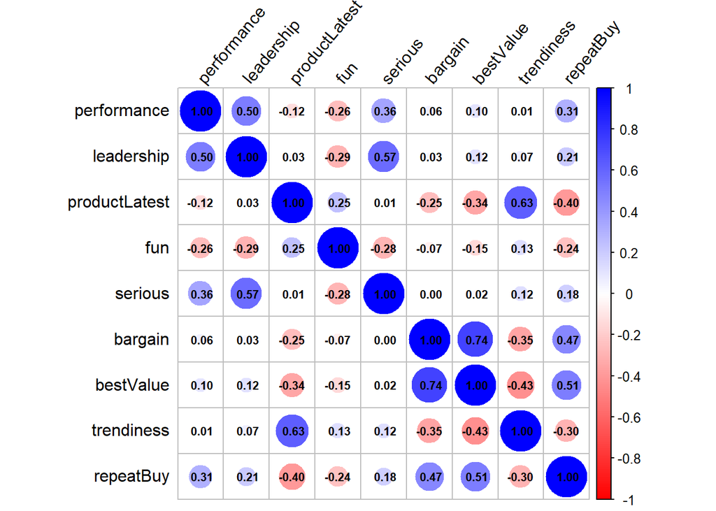

```r
brand_cor <- brand[, -which(names(brand) == "name")]

cor_matrix <- cor(brand_cor)

corrplot(cor_matrix, type = "full", order = "original", tl.col = "black", tl.srt = 50, addCoef.col = "black",number.cex = 0.7, col = colorRampPalette(c("red", "white", "blue"))(200))
```

### 3.2 **Define the number of the clusters**

As we are required to compare the relationships among the ordinal variables which are requivalant to the shopping factors, the brand names are supposed to be removed before clustering, not to be biased by brands.

```r
brand_numeric <- prepared_brand |>  select_if(is.numeric)
```

#### 3.2.1 Elbow Method

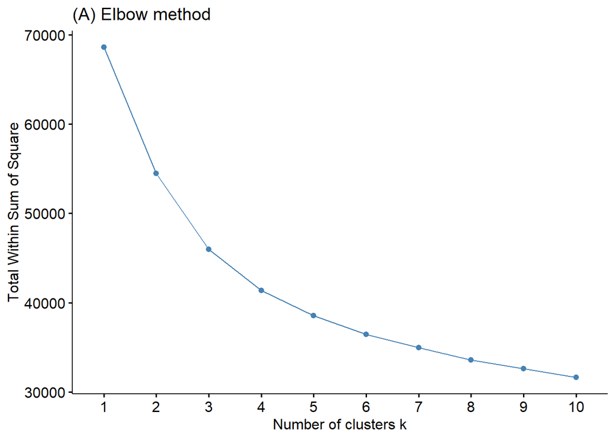

```r
# (A) Elbow method
p1 <- fviz_nbclust(brand_numeric, FUNcluster = hcut, method = "wss",
                   k.max = 10) +
  labs(title="(A) Elbow method")
p1
```

#### 3.2.2 Silhouette Method

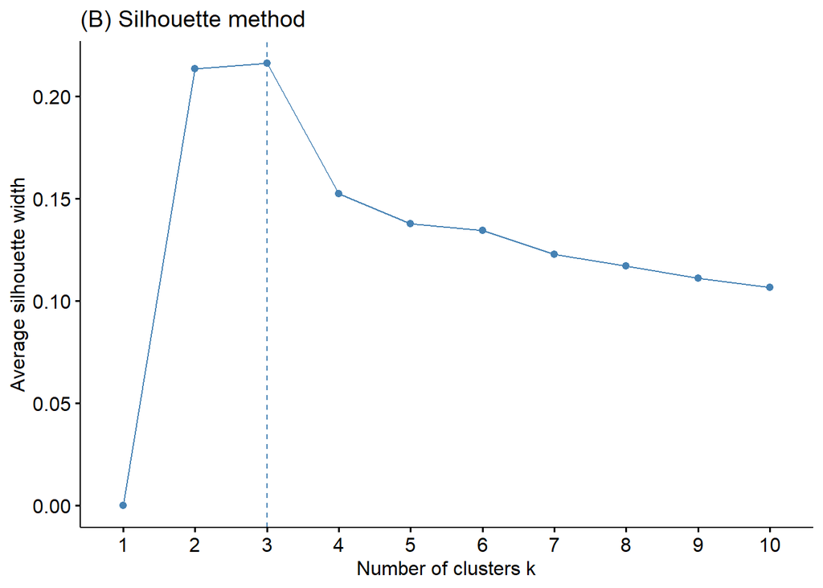

```r
# (B) Silhouette method
p2 <- fviz_nbclust(brand_numeric, FUNcluster = hcut, method = "silhouette",
                   k.max = 10) +
 labs(title="(B) Silhouette method")
p2
```

In the first plot, the Elbow Method, involves plotting the sum of squared distances (inertia) from each point to its assigned cluster center. The “elbow” point in the plot indicates the optimal number of clusters.

In the second plot, the Silhouette Method, involves calculating the average silhouette scores for different numbers of clusters. The optimal number of clusters maximizes the average silhouette score.

The optimal number of clusters is 3 in this analysis.

### 3.3 Create Clusters

| cluster | n |
| --- | --- |
| 1 | 270 |
| 2 | 494 |
| 3 | 236 |

| cluster | performance | leadership | productLatest | fun | serious | bargain | bestValue | trendiness | repeatBuy |
| --- | --- | --- | --- | --- | --- | --- | --- | --- | --- |
| 1 | 7.407407 | 7.100000 | 7.185185 | 4.507407 | 7.185185 | 3.537037 | 3.781481 | 6.466667 | 3.792593 |
| 2 | 2.497976 | 2.983806 | 7.435223 | 7.340081 | 2.882591 | 3.491903 | 3.429150 | 5.939271 | 2.334008 |
| 3 | 5.313559 | 4.347458 | 2.466102 | 5.190678 | 4.063559 | 6.690678 | 6.872881 | 2.288136 | 6.567797 |

#### 3.3.1 The frequencies of clusters by brand

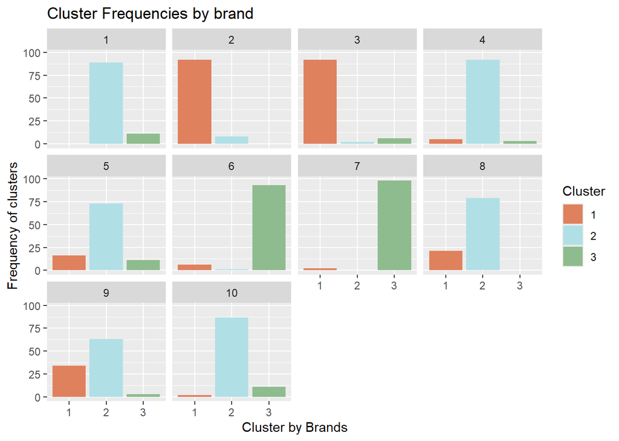

#### 3.3.2 **Interpretation of the frequency distribution**

This chart displays the frequency distribution（ between 0 and 100）of clusters across different brands (labeled ‘a’ to ‘j’).

In terms of clustering, cluster 1 mainly contains brands b and c, cluster 2 mainly contains brands a, d, e, h, i and j, and cluster 3 mainly contains brands f and g.

### 3.4 The box plots representing the relationships among variables and repeatBuy

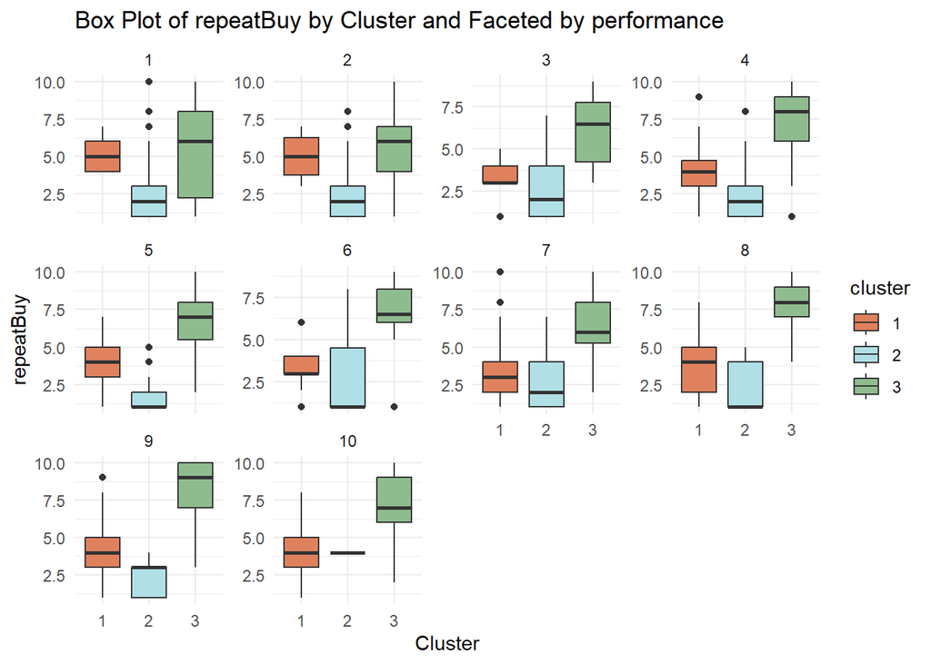

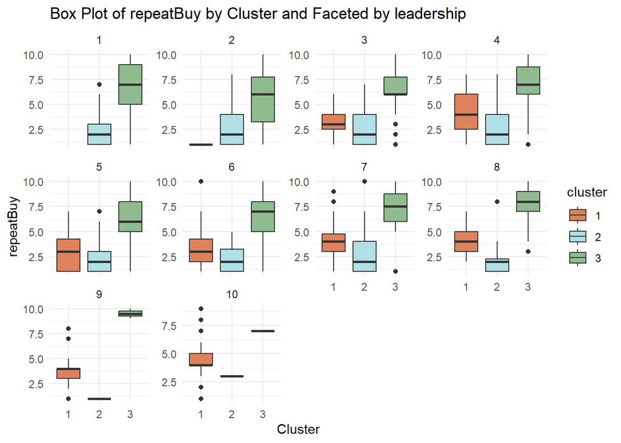

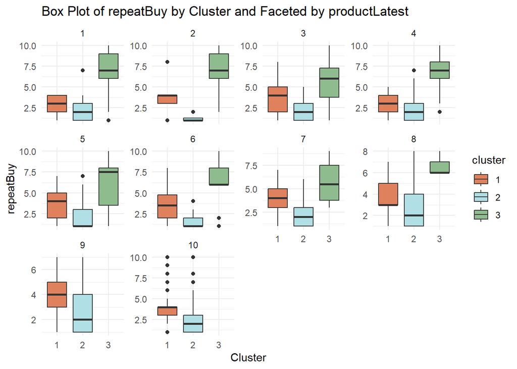

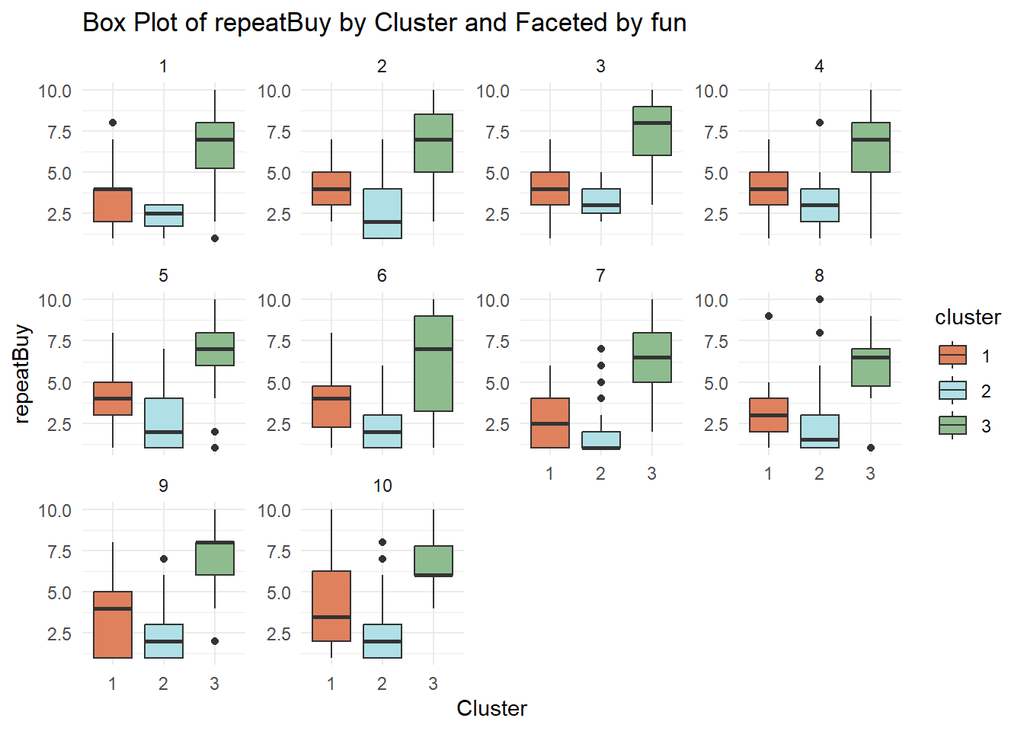

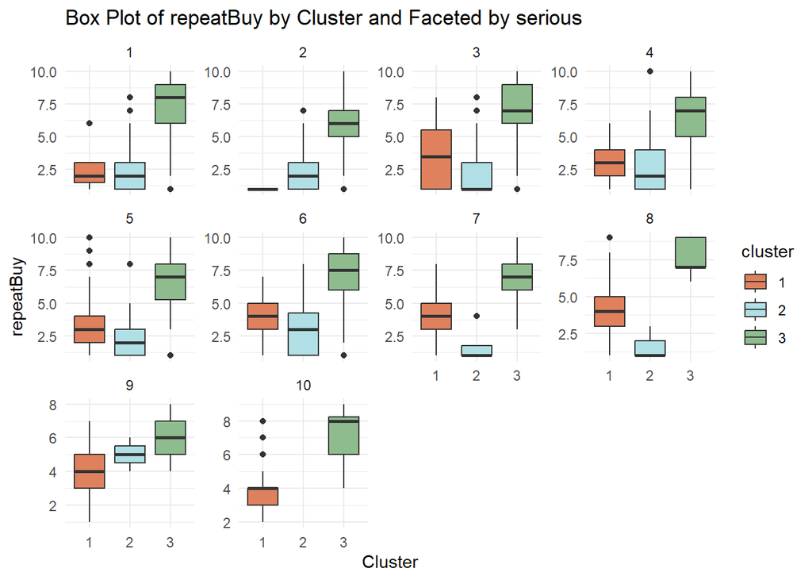

[figure not shown]

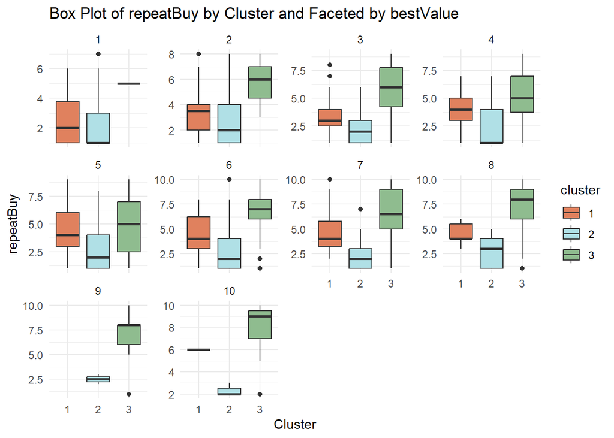

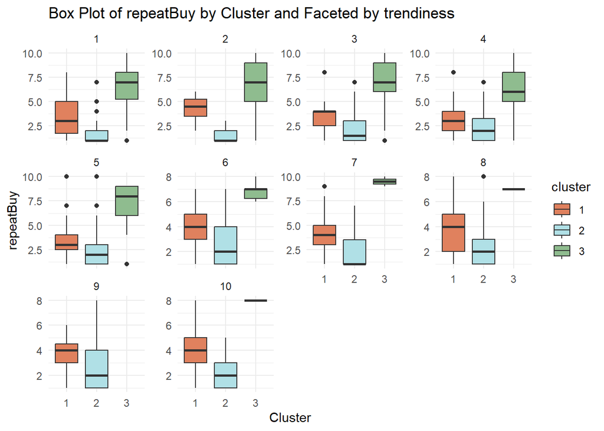

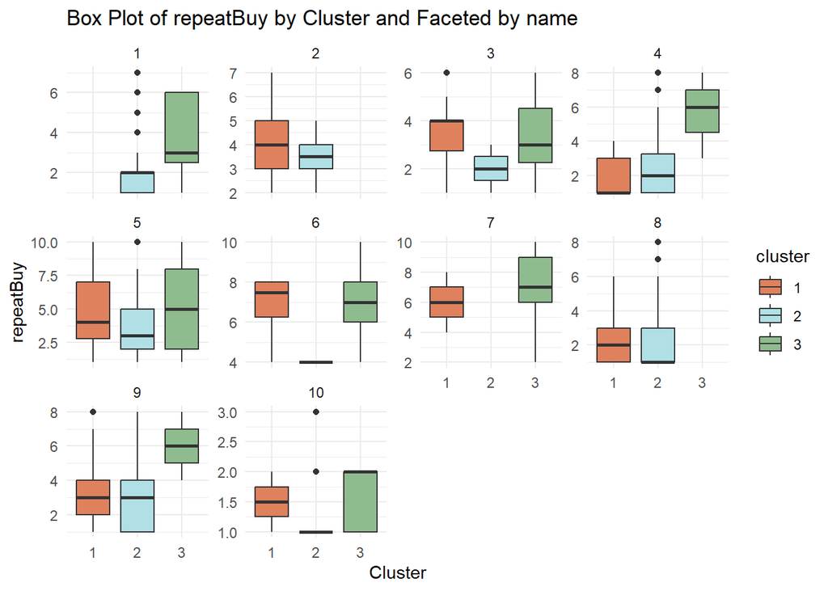

#### 3.4.1 Interpretation of the box plots

These charts represent the box plot of repeat buy by cluster and faceted by performance, leadership ,product lastest, fun, serious, bargain, best value and trendiness.

For the box plot of repeat buy by cluster and faceted by performance, cluster 3 had the highest median, followed by cluster 1, and the lowest median was for cluster 2. The overall lower outliers for cluster 3 compared to clusters 1 and 2 suggest that there is a difference in repeat purchase rates for clusters 1 and 2.

For the box plot of repeat buy by cluster and faceted by leadership, similar to the performance in performance, Cluster 3 has the highest median, followed by Cluster 1 and Cluster 2. Overall the outliers for clusters 1 and 3 are generally higher. When repeat buy is 9 and 10, cluster 1 has more distribution than cluster 2 and 3.

For the box plot of repeat buy by cluster and faceted by product lastest, in this set of box plots, cluster 3 has the highest median, followed by cluster 1, and cluster 2 is the lowest. Clusters 1 and 2 have more outliers. Cluster 3 has no distribution at all when the repeat buy is 9 and 10 and there are very many outliers for clusters 1 and 2 when the repeat buy is 10, which means that the variance is very high at this point.

For the box plot of repeat buy by cluster and faceted by fun,cluster 3 has the highest median, followed by cluster 1, and cluster 2 is the lowest. Cluster 2 has significantly more outliers overall.

For the box plot of repeat buy by cluster and faceted by serious, cluster 3 has the highest median and both cluster 1 and 2 have relatively low medians. Cluster 1 has significantly more outliers and a wider distribution of IQRs than clusters 2 and 3, implying that cluster 1 is more variable in this dimension.

For the box plot of repeat buy by cluster and faceted by bargain, cluster 3 has the highest median, followed by cluster 1, and cluster 2 has the lowest low median. The distribution of outliers for these three clusters is relatively even.

For the box plot of repeat buy by cluster and faceted by best value, cluster 3 has the highest median, followed by cluster 1, and cluster 2 has the lowest low median. Clusters 1 and 3 have a higher distribution of outliers. The distribution of cluster 3 is very less when repeat buy is 1, while the distribution of clusters 1 and 2 is very less when repeat buy is 9 and 10.

For the box plot of repeat buy by cluster and faceted by trendiness, cluster 3 has the highest median followed by cluster 1 and cluster 2 has the lowest median. The distribution of outliers is more for clusters 1 and 2. When repeat buy is greater than 7, the distribution of cluster 3 is significantly less than that of clusters 1 and 2.

#### 3.4.2 Overall Interpretations

**Cluster 1:**

**Cluster 2:**

**Cluster 3:**

## 4 Principal Component Analysis (PCA)

#### 4.0.1 Descriptive analysis of categorical variables

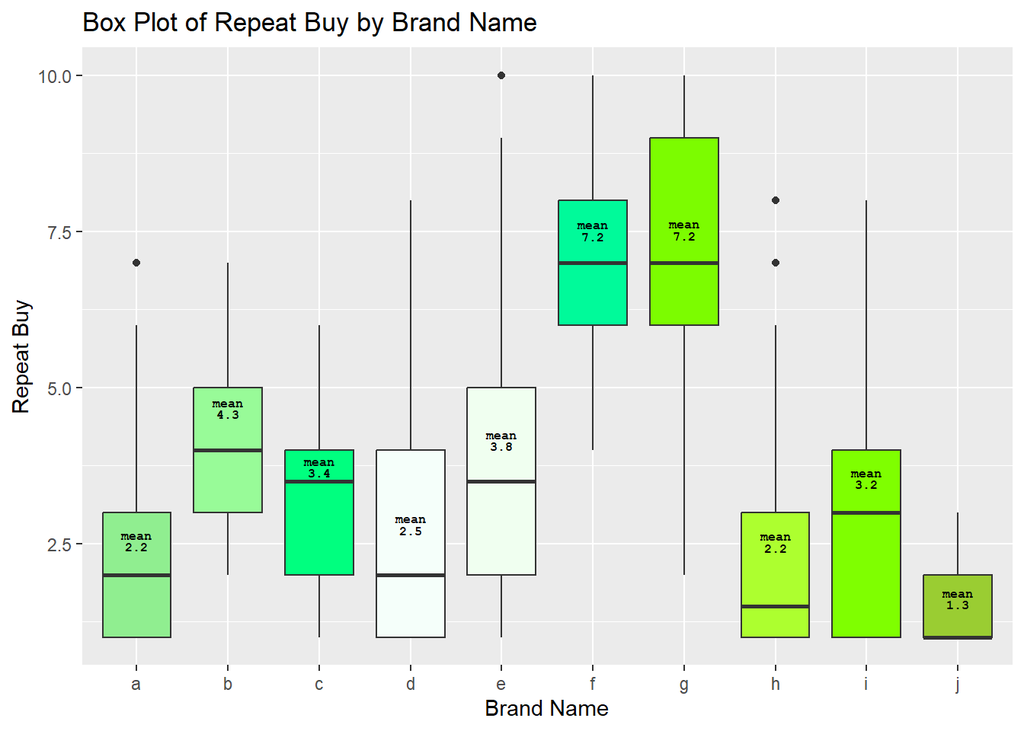

#### 4.0.2 Prep the recipe

#### 4.0.3 Extract PCA components

**PCA components**

| terms | value | component | id |
| --- | --- | --- | --- |
| variance | 3 | 1 | pca |
| variance | 2 | 2 | pca |
| variance | 1 | 3 | pca |
| variance | 1 | 4 | pca |
| variance | 1 | 5 | pca |
| variance | 0 | 6 | pca |
| variance | 0 | 7 | pca |
| variance | 0 | 8 | pca |
| cumulative variance | 3 | 1 | pca |
| cumulative variance | 5 | 2 | pca |
| cumulative variance | 6 | 3 | pca |
| cumulative variance | 6 | 4 | pca |
| cumulative variance | 7 | 5 | pca |
| cumulative variance | 7 | 6 | pca |
| cumulative variance | 8 | 7 | pca |
| cumulative variance | 8 | 8 | pca |
| percent variance | 31 | 1 | pca |
| percent variance | 26 | 2 | pca |
| percent variance | 13 | 3 | pca |
| percent variance | 9 | 4 | pca |
| percent variance | 8 | 5 | pca |
| percent variance | 5 | 6 | pca |
| percent variance | 4 | 7 | pca |
| percent variance | 3 | 8 | pca |
| cumulative percent variance | 31 | 1 | pca |
| cumulative percent variance | 58 | 2 | pca |
| cumulative percent variance | 71 | 3 | pca |
| cumulative percent variance | 80 | 4 | pca |
| cumulative percent variance | 88 | 5 | pca |
| cumulative percent variance | 93 | 6 | pca |
| cumulative percent variance | 97 | 7 | pca |
| cumulative percent variance | 100 | 8 | pca |

3 pca components extracts 71% of the variation in the 8 variables, as per the above Cumulative Percentage, hence 3 components is deemed sufficient to explain the variation in variables.

#### 4.0.4 Obtain the loading

```
# A tibble: 64 × 4
   terms          value component id
   <chr>          <dbl> <chr>     <chr>
 1 performance    0.242 PC1       pca
 2 leadership     0.219 PC1       pca
 3 productLatest -0.420 PC1       pca
 4 fun           -0.284 PC1       pca
 5 serious        0.164 PC1       pca
 6 bargain        0.436 PC1       pca
 7 bestValue      0.493 PC1       pca
 8 trendiness    -0.418 PC1       pca
 9 performance    0.428 PC2       pca
10 leadership     0.532 PC2       pca
# ℹ 54 more rows
```

In PC1, “productLatest” has the highest negative loading (-0.420), suggesting it inversely impacts this component, while “bestValue” has the highest positive loading (0.493), indicating a strong positive influence. For PC2, “leadership” holds the highest positive loading (0.532), meaning it significantly drives this component, whereas “fun” has the highest negative loading (-0.261), showing an inverse relationship. In PC3, “bargain” is the most significant with a high negative loading (-0.529), suggesting it strongly inversely impacts this component, while “performance” has the highest positive loading (0.032), though its influence is relatively small compared to the others.

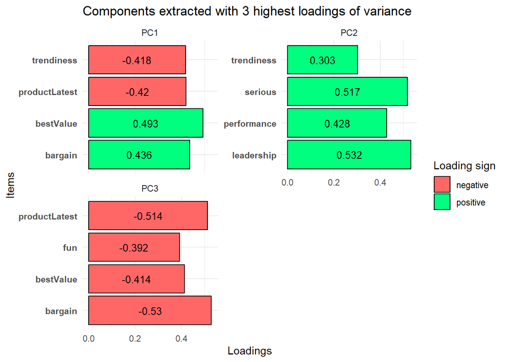

#### 4.0.5 **Interpretation of PCA Components**

**PC1 (Principal Component 1)**: Contrasts value/bargain perception with trendiness/recency.

- **BestValue (0.493)**: This variable has the highest positive loading, suggesting that brands perceived as offering good value are strongly associated with PC1.
- **Bargain (0.436)**: This also has a strong positive loading, indicating that brands seen as bargains are similarly associated with PC1.
- **Trendiness (-0.418)**: This variable has a strong negative loading, suggesting an inverse relationship with PC1. Brands perceived as trendy are less associated with PC1.
- **ProductLatest (-0.420)**: This also has a strong negative loading, indicating that brands with the most recent products are inversely related to PC1.

A higher PC1 score represents a higher chance of customer repurchasing the brand due to positive perception of the brand being good value and bargain, however it also represents lower chances of customers repurchasing the brand due to negative perception of the brand being trendy and latest. We can say PC1 brands represents good value and bargain for customers but not being trendy and latest.

**PC2 (Principal Component 2)**: Emphasizes leadership, seriousness, performance, and trendiness.

- **Leadership (0.532)**: This variable has the highest positive loading on PC2, indicating a strong association.
- **Serious (0.517)**: This also has a strong positive loading, showing a significant relationship with PC2.
- **Performance (0.428)**: This variable has a moderate positive loading on PC2.
- **Trendiness (0.303)**: This has the lowest loading among the top contributors but is still positively associated with PC2.

**PC3 (Principal Component 3)**: Contrasts bargain/value and recent products and fun.

- **Bargain (-0.530)**: This variable has the highest negative loading on PC3, indicating a strong inverse relationship.
- **ProductLatest (-0.514)**: This also has a strong negative loading.
- **BestValue (-0.414)**: This variable has a moderate negative loading.
- **Fun (-0.392)**: This has the lowest loading among the top contributors but is still negatively associated with PC3.

A higher PC3 score represents a lower chance of customer repurchasing the brand due to negative perception of the brand being a bargain, recent product, good value and fun. We can say customers have a negative perception of brands from PC3 being bargain, latest product, value and fun.

## 5 Comparison of PCA Scores with Clusters

##### 5.0.0.1 Prep and Bake the recipe

```
Rows: 1,000
Columns: 14
$ repeatBuy <int> 6, 2, 6, 1, 1, 2, 1, 1, 1, 1, 2, 5, 3, 1, 2, 3, 1, 2, 2, 2, …
$ PC1       <dbl> 0.70208363, -1.27234346, 0.97033026, -0.34325825, 1.59384234…
$ PC2       <dbl> -1.6139918, -1.8687620, -2.2821677, -0.7265777, -3.2033164, …
$ PC3       <dbl> -1.7832971, 2.0516587, -0.6693561, -0.6666432, -1.1081565, -…
$ name_X2   <dbl> 0, 0, 0, 0, 0, 0, 0, 0, 0, 0, 0, 0, 0, 0, 0, 0, 0, 0, 0, 0, …
$ name_X3   <dbl> 0, 0, 0, 0, 0, 0, 0, 0, 0, 0, 0, 0, 0, 0, 0, 0, 0, 0, 0, 0, …
$ name_X4   <dbl> 0, 0, 0, 0, 0, 0, 0, 0, 0, 0, 0, 0, 0, 0, 0, 0, 0, 0, 0, 0, …
$ name_X5   <dbl> 0, 0, 0, 0, 0, 0, 0, 0, 0, 0, 0, 0, 0, 0, 0, 0, 0, 0, 0, 0, …
$ name_X6   <dbl> 0, 0, 0, 0, 0, 0, 0, 0, 0, 0, 0, 0, 0, 0, 0, 0, 0, 0, 0, 0, …
$ name_X7   <dbl> 0, 0, 0, 0, 0, 0, 0, 0, 0, 0, 0, 0, 0, 0, 0, 0, 0, 0, 0, 0, …
$ name_X8   <dbl> 0, 0, 0, 0, 0, 0, 0, 0, 0, 0, 0, 0, 0, 0, 0, 0, 0, 0, 0, 0, …
$ name_X9   <dbl> 0, 0, 0, 0, 0, 0, 0, 0, 0, 0, 0, 0, 0, 0, 0, 0, 0, 0, 0, 0, …
$ name_X10  <dbl> 0, 0, 0, 0, 0, 0, 0, 0, 0, 0, 0, 0, 0, 0, 0, 0, 0, 0, 0, 0, …
$ cluster   <fct> 3, 2, 3, 2, 3, 2, 2, 2, 2, 2, 2, 2, 2, 2, 2, 3, 2, 2, 2, 2, …
```

### 5.1 Compare principal component scores with clusters

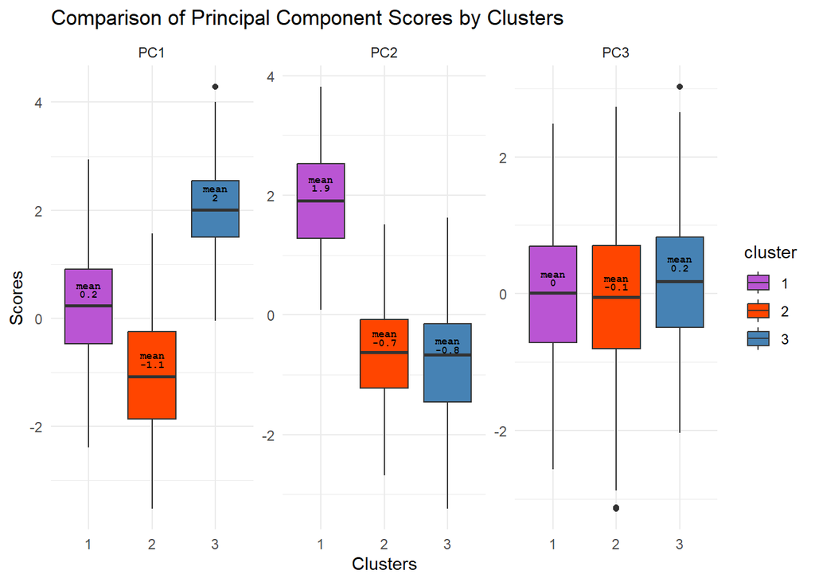

#### 5.1.2 Interpretation of Clusters

*Cluster 1 (Purple):*

*Cluster 2 (Orange):*

*Cluster 3 (Blue):*

#### 5.1.3 Interpretation of Principal Components

PC1 was interpreted as contrasting value/bargain perception against trendiness/recency. The cluster analysis suggests cluster 3 is strongly associated with the value/bargain side, cluster 2 with the trendy/recent side, and cluster 1 is somewhat in the middle.

## 6 Analysis of Factors Influencing Repeat Purchase

##### 6.0.0.1 Prepare the Data

```
Rows: 1,000
Columns: 14
$ repeatBuy <int> 6, 2, 6, 1, 1, 2, 1, 1, 1, 1, 2, 5, 3, 1, 2, 3, 1, 2, 2, 2, …
$ PC1       <dbl> 0.70208363, -1.27234346, 0.97033026, -0.34325825, 1.59384234…
$ PC2       <dbl> -1.6139918, -1.8687620, -2.2821677, -0.7265777, -3.2033164, …
$ PC3       <dbl> -1.7832971, 2.0516587, -0.6693561, -0.6666432, -1.1081565, -…
$ cluster   <fct> 3, 2, 3, 2, 3, 2, 2, 2, 2, 2, 2, 2, 2, 2, 2, 3, 2, 2, 2, 2, …
$ b         <dbl> 0, 0, 0, 0, 0, 0, 0, 0, 0, 0, 0, 0, 0, 0, 0, 0, 0, 0, 0, 0, …
$ c         <dbl> 0, 0, 0, 0, 0, 0, 0, 0, 0, 0, 0, 0, 0, 0, 0, 0, 0, 0, 0, 0, …
$ d         <dbl> 0, 0, 0, 0, 0, 0, 0, 0, 0, 0, 0, 0, 0, 0, 0, 0, 0, 0, 0, 0, …
$ e         <dbl> 0, 0, 0, 0, 0, 0, 0, 0, 0, 0, 0, 0, 0, 0, 0, 0, 0, 0, 0, 0, …
$ f         <dbl> 0, 0, 0, 0, 0, 0, 0, 0, 0, 0, 0, 0, 0, 0, 0, 0, 0, 0, 0, 0, …
$ g         <dbl> 0, 0, 0, 0, 0, 0, 0, 0, 0, 0, 0, 0, 0, 0, 0, 0, 0, 0, 0, 0, …
$ h         <dbl> 0, 0, 0, 0, 0, 0, 0, 0, 0, 0, 0, 0, 0, 0, 0, 0, 0, 0, 0, 0, …
$ i         <dbl> 0, 0, 0, 0, 0, 0, 0, 0, 0, 0, 0, 0, 0, 0, 0, 0, 0, 0, 0, 0, …
$ j         <dbl> 0, 0, 0, 0, 0, 0, 0, 0, 0, 0, 0, 0, 0, 0, 0, 0, 0, 0, 0, 0, …
```

##### 6.0.0.2 Setup Recipe

```
── Recipe ──────────────────────────────────────────────────────────────────────
```

```
── Inputs
```

```
Number of variables by role
```

```
outcome:    1
predictor: 13
```

```
── Operations
```

```
• Centering and scaling for: all_numeric_predictors()
```

```
• Dummy variables from: all_nominal_predictors()
```

### 6.1 Model Development

#### 6.1.1 Define the model

```
Linear Regression Model Specification (regression)

Computational engine: lm
```

#### 6.1.2 Create the workflow

```
══ Workflow ════════════════════════════════════════════════════════════════════
Preprocessor: Recipe
Model: linear_reg()

── Preprocessor ────────────────────────────────────────────────────────────────
2 Recipe Steps

• step_normalize()
• step_dummy()

── Model ───────────────────────────────────────────────────────────────────────
Linear Regression Model Specification (regression)

Computational engine: lm
```

#### 6.1.3 Fit the model

```
══ Workflow [trained] ══════════════════════════════════════════════════════════
Preprocessor: Recipe
Model: linear_reg()

── Preprocessor ────────────────────────────────────────────────────────────────
2 Recipe Steps

• step_normalize()
• step_dummy()

── Model ───────────────────────────────────────────────────────────────────────

Call:
stats::lm(formula = ..y ~ ., data = data)

Coefficients:
(Intercept)          PC1          PC2          PC3            b            c
     3.8421       0.3258      -0.1066      -0.2947       0.5518       0.3470
          d            e            f            g            h            i
     0.2734       0.4133       1.1376       1.1250       0.1327       0.3812
          j   cluster_X2   cluster_X3
    -0.2228      -0.4974       0.5534
```

### 6.2 Interpret the results

**Linear Regression Results**

| term | estimate | p.value |
| --- | --- | --- |
| (Intercept) | 3.8421361 | 1.812458e-91 |
| PC1 | 0.3258048 | 1.146124e-03 |
| PC2 | -0.1065947 | 2.982900e-01 |
| PC3 | -0.2946554 | 3.428169e-07 |
| b | 0.5518088 | 1.107524e-08 |
| c | 0.3470022 | 3.133610e-04 |
| d | 0.2734432 | 3.349442e-04 |
| e | 0.4132519 | 1.889629e-08 |
| f | 1.1375543 | 7.603756e-30 |
| g | 1.1250411 | 1.193237e-28 |
| h | 0.1327365 | 8.657522e-02 |
| i | 0.3811577 | 6.239035e-07 |
| j | -0.2228147 | 1.462694e-03 |
| cluster_X2 | -0.4974322 | 2.947149e-02 |
| cluster_X3 | 0.5533705 | 6.807553e-02 |

#### 6.2.1 Interpretation of PCA

PC1 has a positive coefficient (0.3258048) and a p-value less than 0.05, indicating that it is a statistically significant. A positive PC1 value , which contrasts value/bargain perception with trendiness/recency, is associated with a higher likelihood of customers repurchasing the products.

PC2 has a negative coefficient (-0.1065947) and a p-value greater than 0.05, suggesting that it is not a statistically. PC2, which emphasizes leadership, seriousness, performance, and trendiness, does not have a significant effect on the likelihood of customers repurchasing the products.

PC3 has a negative coefficient (-0.2946554) and a p-value less than 0.05, indicating that it is a statistically significant. A negative PC3 value, which contrasts bargain/value and recent products with fun, is associated with a higher likelihood of customers repurchasing the products.

#### 6.2.2 Interpretation of clusters

- Cluster 1 is the baseline for the regression, the interpretation of the regression results for Clusters 2 and 3 will be in comparison to Cluster 1. The coefficient of cluster 2 and 3 are (-0.4974322) and (0.5533705) respectively. This suggest cluster 1 customers are expected to purchase frequently more than customers of cluster 2 but less than them of cluster 3.
- Cluster 2 p-value is lower than the signifance level of 0.05 making it statistically significant. The negative coefficient (-0.4974322) suggests brands in this cluster struggle with customer retention and repeat purchases, exhibiting lower repeat buying behavior compared to Cluster 1
- Cluster 3 has positive impact on repeat buying behavior compared to Cluster 1, however the result is insignificant, due to its p-value (0.07) being higher than the significance level of 0.05.

#### 6.2.3 Interpretation of categorical variable

```
 [1] "a" "b" "c" "d" "e" "f" "g" "h" "i" "j"
```

The intercept term (3.84) represents the estimated mean value of the dependent variable (repeatBuy) when all other predictors are set to zero. Brand name ‘a’ is our baseline variable for this regression as it will be used in comparision with other brand name variables. Brand name ‘h’ is insignificant above due to its p-value being higher than signifcant level of 0.05.

Brand names ‘b’, ‘c’, ‘d’, ‘e’, ‘f’, ‘g’ and ‘i’ are significant and the positive coefficients likely suggest higher values are associated with increased chances of customers buying product again compared with brand ‘a’, with brand name ‘f’ and ‘g’ having the highest chance of customers repeat buying, compared to brand ‘a’.

Brand name ‘j’ is significant and has a negative coefficient, suggesting higher values are associated with lower chances of customers repeat buying compared to the brand ‘a’.